# Crime Mapping, or the story of where (we think) crimes occur

Sebastian Martinez - Fabian Bohnenberger

# Crime in Chicago. FAQ.

Welcome. Throughout this website we are going to present the results from our research on the location of crime in the city of Chicago.

**Our Format:** Frequently Asked Questions.

**Why** *(We get asked frequently)***?** Sometimes it’s easier to guide the audience through the logic of an argument, if you give them the questions.

And so, with out many introductions:

## MAPS, MAPS, MAPS

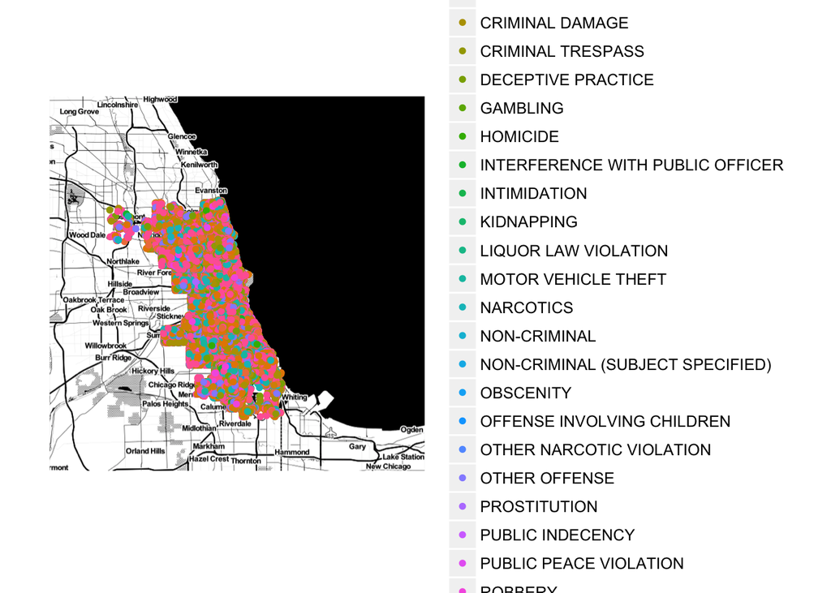

This idea can clearly be seen in the following image. Gambling and prostitution are clear examples of how the location of the crime is affected by something. Our initial hypothesis is that the presence of the police, determined by the location of the police headquarters for the district affect the actual place where crimes occur.

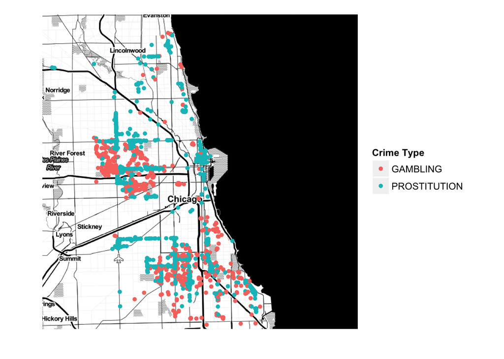

We wanted to see whether the crimes being committed (and reported) were so in relation to the police station of its respective district. Then we would like to know if this relation is deterministic. And if so, in what direction.

Formally: *Does the physical location of police stations and the organizational demarcation of police districts have a statistically significant effect on the spatial distribution of crime in the city of Chicago?* This can be done in some simple steps:

**-**: The farther away from the police station, the more crimes are committed.

**-**: Specific crimes are mostly perpetrated near the district borders; their chance to occur closer to police stations is low.

## SOME INITIAL RESULTS?

We looked at the position of the crimes in relation to the police districs, and *scientifically* wondered: Do criminals systematically choose where to commit their crimes given the location of the police?

After some very careful data manipulation, we arrived at the following **conclusions**:

- In general, criminals do not seem to take the position of the police district when committing their crimes. This has important implications with respect to the power police have over their jurisdictions.

Such a result can be seen in the following regression output:

Predicted Probabilities for Fitted Values

| hardship_index | violent | predicted |
| --- | --- | --- |
| 53.308 | 0 | 0.029 |
| 53.308 | 1 | 0.028 |

The output presented here shows that when controlling for the specific socioeconomic characteristics of each of the specific districts, there is not a statistically significant difference in the probability that a crime would be committed close or far to the police station for every district.

### How did we develop this idea?

We ran a regression considering the *relative* position of a crime to the police station. With this information we ran a probabilistic model that determines what is the probability of a certain outcome, given two or more different options. In our case, the “outcome” is that crime is committed farther away from the station. The options? That the crime is violent or non violent. As seen in the table above.

In search for robustness, we tried to mix things up and look at different “categories of crimes”. The results hold when looking if the crimes are considered money-related, or if they are considered a property crime. For none of these differentiations we could find a significant difference on the probability that the crime is commited farther away from the station. We tried looking for a different specification of socioeconomic characteristics and looking at the individual components of the Hardship index. Same. No difference

## What’s next, then?

Well, we tried many specifications, to see if there was something we could rescue from our analysis. It turns out that if you look at prostitution, there is an important difference in where crimes are committed in relation to the center of a police station. Let’s have a look:

Predicted Probabilities for Fitted Values

| PerCapitaIncome | 16+Unemployed% | HouseholdsPoverty% | 25+WithoutHighSchool% | HousingCrowded% | Under18Over64% | Prostitution | predicted |
| --- | --- | --- | --- | --- | --- | --- | --- |
| 25726.78 | 16.299 | 23.768 | 20.164 | 4.782 | 34.478 | 0 | 0.028 |
| 25726.78 | 16.299 | 23.768 | 20.164 | 4.782 | 34.478 | 1 | 0.065 |

As it can be seen, prostitution has a very clear behavior with respect to the location of the police station. It may very well be a consequence of clustering of the sex industries in places where there was historically less coverage of the police.

## SOME CONCLUDING REMARKS

Based on observations of reported crimes, the location of police stations and the organizational demarcation of police power in the city of Chicago we tried to assess the spatial distribution of crime. We posed the question whether crime occurs primarily farther away from the police station and whether the borders of police districts have a statistically significant effect on the distribution of crime. Our main conclusion is that given the data and the specifics of approach used in this research, there is no systematic behavior from the criminals in relation to the police station.

# FURTHER INFORMATION

**-The complete document can be found in the following link:** [Here:](https://rawgit.com/fabianbohnenberger/CrimeMapping2/master/ResearchPaper.html)

**-Note: An interactive version of the maps shown in website is available for download in the link provided** Please make a local version of the following [repository:](https://github.com/fabianbohnenberger/CrimeMapping2/tree/master) and run the file “crime.R”